# CS 422

Gabriel Johnson, Artificial Intelligence Undergraduate

### Part 2.1

```r
library(olsrr)
```

### Part 2.1-a.

```r
no_names <- select(train.df,-name)
model <- lm(mpg ~ ., data=no_names)
print(model)
```

```
Call:
lm(formula = mpg ~ ., data = no_names)

Coefficients:
 (Intercept)     cylinders  displacement    horsepower        weight  acceleration          year        origin
  -16.598211     -0.523480      0.020422     -0.017497     -0.006416      0.087418      0.738273      1.516023
```

### Part 2.1-a.i

The name of the car doesn’t impact the millage the car gets per gallon. Compared to how the other predictors does like how many cylinders the car has. It makes the data less biased as well since it is the raw data instead of tied to a name.

### Part 2.1-a.ii

```r
summary <- summary(model)
###ols_regress(model, data = no_names)
r_squared <- summary$r.squared
adj_rval <- summary$adj.r.squared
res_error <- summary$sigma
predict <- predict(model,no_names)
rmse2 <- sqrt (res_error^2)
cat(paste0("R-sq value is ",  round(r_squared, digits = 2)),paste0("\nAdjusted R-sq value is ",  round(adj_rval, digits = 2)),paste0("\nRSE is ", round(res_error, digits = 2)),paste0("\nRMSE is ", rmse2))
```

```
R-sq value is 0.82
Adjusted R-sq value is 0.81
RSE is 3.37
RMSE is 3.36691839200609
```

### Part 2.1-a.iii

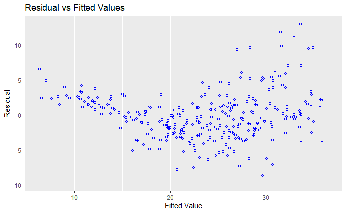

### Part 2.1-a.i.v

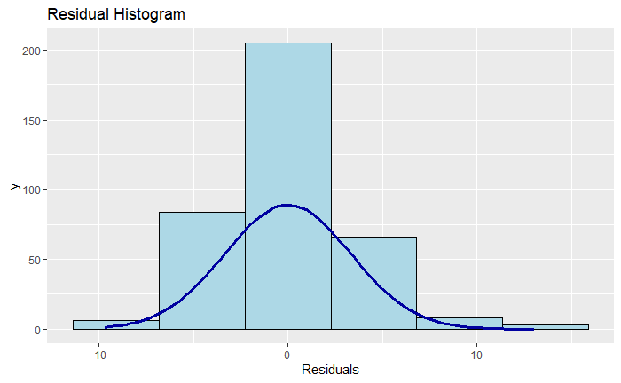

The following Histogram for the residuals of the Model with the density of the model is roughly like a Gaussian distribution, this is because of the bell curve which can be traced along the rising bars on the histogram.Both sides of the histogram are roughly equal in distribution with more of a tail on the right, but the main values are in the middle which follows the normal Gaussian bell curve.The distribution is weighted heavily on the middle of the graph around a residual between positive and negative -2. Which means that those values have a closer to zero meaning that the fit is more consistant with those attributes when being compared to the mpg of the training data.

### Part 2.1-b.i

```r
anova(model)
```

```
Analysis of Variance Table

Response: mpg
              Df  Sum Sq Mean Sq   F value    Pr(>F)
cylinders      1 13618.3 13618.3 1201.3156 < 2.2e-16 ***
displacement   1  1024.5  1024.5   90.3720 < 2.2e-16 ***
horsepower     1   354.3   354.3   31.2510 4.454e-08 ***
weight         1   871.4   871.4   76.8657 < 2.2e-16 ***
acceleration   1     0.5     0.5    0.0411    0.8395
year           1  2246.1  2246.1  198.1343 < 2.2e-16 ***
origin         1   311.3   311.3   27.4568 2.726e-07 ***
Residuals    364  4126.4    11.3
---
Signif. codes:  0 ‘***’ 0.001 ‘**’ 0.01 ‘*’ 0.05 ‘.’ 0.1 ‘ ’ 1
```

```r
signif <- select(train.df,-name & -horsepower & -acceleration & -origin & -year)
model_2 <- lm(mpg ~.,signif)
print(model_2)
```

```
Call:
lm(formula = mpg ~ ., data = signif)

Coefficients:
 (Intercept)     cylinders  displacement        weight
   44.125866     -0.268020     -0.013970     -0.005549
```

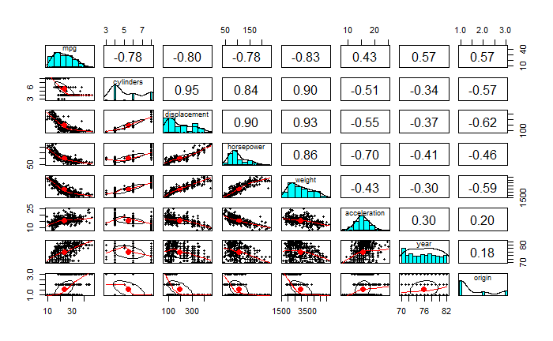

```r
pairs.panels(no_names)
```

### Part 2.1-b.ii

```r
cat(paste0("R-sq value is ",  r_squared2),paste0("\nAdjusted R-sq value is ",  adj_rval2),paste0("\nRSE is ", res_error),paste0("\nRMSE is ", rmse))
```

```
R-sq value is 0.695736781259022
Adjusted R-sq value is 0.693256374584503
RSE is 3.36691839200609
RMSE is 4.31815722035793
```